# Naples Reef Purple Urchins (2010)

Devin Ngo

10/25/2021

# Introduction

This data explores the size frequency distribution of red and purple sea urchins recorded by Santa Barbara Coastal Long Term Ecological Research program divers at long-term kelp removal experiment sites. For this report, we will specifically be looking at data for purple urchins in the Naples Reef in 2010.

**Data Citation:** Reed, D. 2020. SBC LTER: Reef: Long-term experiment: Kelp removal: Urchin size frequency distribution ver 20. Environmental Data Initiative. https://doi.org/10.6073/pasta/5a1e9ef03aa47bd2225c0bb98a02a63b.

# Setup

```r
knitr::opts_chunk$set(echo = TRUE, message = FALSE, warning = FALSE)

# Attach Packages
library(tidyverse)
library(here)
library(janitor)
library(kableExtra)
library(lubridate)
```

# Read in Urchins Data

```r
# Read in data
urchins <- read_csv(here("data", "urchins.csv")) %>%
  clean_names()
```

For reference, the first 6 lines of the data set are shown below:

```r
# Return the first 6 lines
head(urchins)
```

```
## # A tibble: 6 × 6
##   date     site  treatment  size scientific_name               common_name
##   <chr>    <chr> <chr>     <dbl> <chr>                         <chr>
## 1 10/10/08 NAPL  CONTROL     2.5 Strongylocentrotus purpuratus Purple Urchin
## 2 10/10/08 NAPL  CONTROL     2.5 Strongylocentrotus purpuratus Purple Urchin
## 3 10/10/08 NAPL  CONTROL     2.5 Strongylocentrotus purpuratus Purple Urchin
## 4 10/10/08 NAPL  CONTROL     2.5 Strongylocentrotus purpuratus Purple Urchin
## 5 10/10/08 NAPL  CONTROL     2.5 Strongylocentrotus purpuratus Purple Urchin
## 6 10/10/08 NAPL  CONTROL     2.5 Strongylocentrotus purpuratus Purple Urchin
```

# Wrangling Data

Wrangling the urchins data to only include Naples Reef observations for purple urchins observed in 2010.

```r
purple_urchins_2010 <- urchins %>%
  filter(common_name %in% c("Purple Urchin")) %>%
  mutate(date_class = mdy(date)) %>%
  mutate(year = year(date_class)) %>%
  filter(year %in% c("2010")) %>%
  filter(site %in% c("NAPL"))
```

# Data Visualization

Exploratory faceted histogram for the size distribution of purple urchins at Naples in 2010, separated by treatment (Control and Annual), to assess normality.

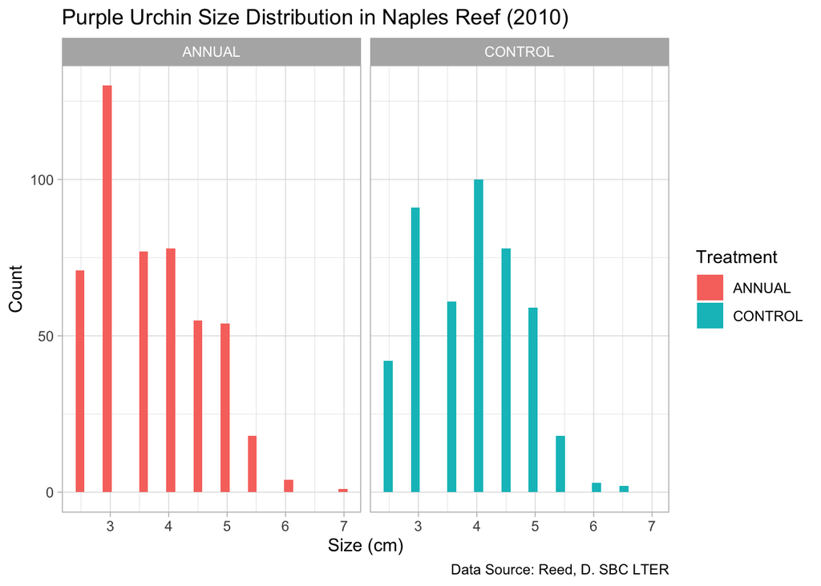

```r
ggplot(data = purple_urchins_2010,
       aes(x = size)) +
  geom_histogram(aes(fill = treatment)) +
  facet_wrap(~treatment) +
  labs(x = "Size (cm)",
       y = "Count",
       title = "Purple Urchin Size Distribution in Naples Reef (2010)",
       fill = "Treatment",
       caption = "Data Source: Reed, D. SBC LTER") +
  theme_light()
```

Exploratory QQ-plots for the size distribution of purple urchins at Naples in 2010, separated by treatment (Control and Annual), to assess normality.

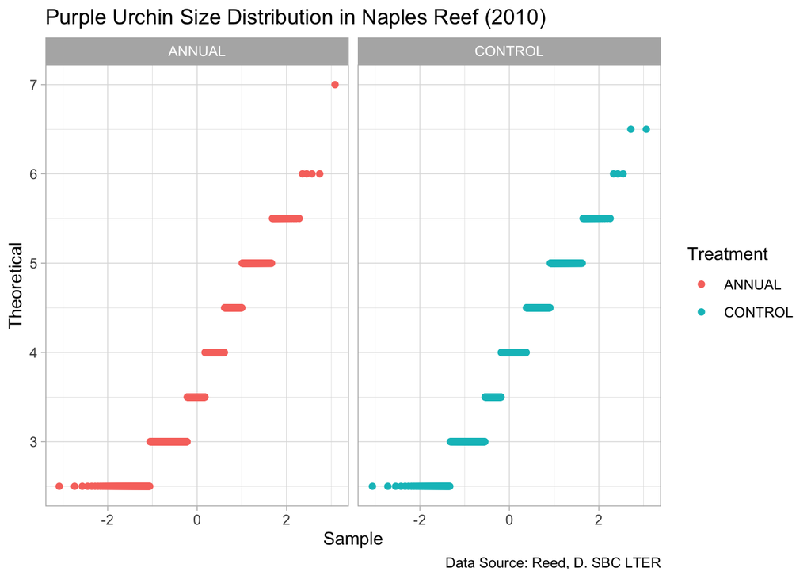

```r
ggplot(data = purple_urchins_2010) +
  geom_qq(aes(sample = size, color = treatment)) +
  facet_wrap(~treatment) +
  labs(x = "Sample",
       y = "Theoretical",
       title = "Purple Urchin Size Distribution in Naples Reef (2010)",
       color = "Treatment",
       caption = "Data Source: Reed, D. SBC LTER") +
  theme_light()
```

**Takeaways:** For both the annual and control treatments, the purple urchins seem to be normally distributed with a slight positive skew when looking at the histogram. When looking at the QQ-plot, both treatments seem fairly linear, which indicates a normal distribution.

# Descriptive Data Table

Creating a finalized basic summary table of descriptive statistics for both groups, including the mean, standard deviation, and sample size by treatment.

```r
purple_urchins_summary <- purple_urchins_2010 %>%
  group_by(treatment) %>%
  summarize (mean_size = round(mean(size),3),
             median_size = round(median(size),3),
             sd_size = round(sd(size),3),
             n = n()) %>%
  kable(col.names = c("Treatment",
                      "Mean Size (cm)",
                      "Median Size (cm)",
                      "Standard Deviation of Size (cm)",
                      "Sample Size (n)")) %>%
  kable_styling(full_width = FALSE)

# Included echo=FALSE in the next code chunk so the caption would appear above the following table
```

**Figure 3. Summary table for purple urchins in the Naples Reef in 2010.** This data separates the purple urchins by treatment (Annual and Control) and includes their mean, standard deviation, and sample size.

| Treatment | Mean Size (cm) | Median Size (cm) | Standard Deviation of Size (cm) | Sample Size (n) |
| --- | --- | --- | --- | --- |
| ANNUAL | 3.681 | 3.5 | 0.898 | 488 |
| CONTROL | 3.893 | 4.0 | 0.865 | 454 |